# Team 6 Applied Exercise

Carrington Metts

3/5/2021

## Objective

The goal of this exercise is to use a support vector classifier and support vector machines (SVMs) to predict whether a car will get high or low gas mileage. To do so, we will use the Auto dataset from the ISLR library. The dataset contains 392 observations of 9 variables.

## Load Data

The Auto data comes from the ISLR library. We will also use various SVM functions from the e1071 library.

```r
rm(list=ls())
library(ISLR) #Auto data
library(e1071) #SVM functions
data(Auto)
```

## Prepare the Data

The goal of the problem is to predict a car’s mileage (MPG) based on the other 8 variables. In the original dataset, mpg is a continuous numeric variable. Recall that support vector classifiers and machines are typically applied to binary classification problems. Therefore, we must first create a new variable that is 0 if the MPG is below the dataset’s median, and 1 otherwise. In order for the support vector classifier and machine to work, the variable must be coded as a factor.

```r
#find median MPG
medianMPG <- median(Auto$mpg)
#code MPG as a factor
Auto$binaryMPG <- as.factor(Auto$mpg > medianMPG)
```

The new binaryMPG variable will be TRUE if the car has better gas mileage than the median, and FALSE otherwise.

Now that the new representation of mpg has been created, we must remove the original mpg from the dataframe. We also remove the name variable, since it is a factor that will introduce a large number of unwanted coefficients into the model.

```r
Auto <- subset(Auto, select=-c(mpg, name))
```

Finally, we want to scale the numeric columns to have a mean of 0 and a standard deviation of 1. This can be done automatically when creating one SVM model, but not when performing cross-validation, as we are about to do.

```r
Auto$cylinders <- scale(Auto$cylinders)
Auto$displacement <- scale(Auto$displacement)
Auto$horsepower <- scale(Auto$horsepower)
Auto$weight <- scale(Auto$weight)
Auto$acceleration <- scale(Auto$acceleration)
Auto$year <- scale(Auto$year)
Auto$origin <- scale(Auto$origin)
```

## Support Vector Classifier

### Explanation

As a reminder, a support vector classifier (also known as a soft margin classifier) creates a linear hyperplane to separate the dataset into two regions. Now that the response variable (MPG) has been converted to a binary categorical form, we can apply a support vector classifier to predict whether a car’s MPG will fall below the median.

In this case, we assume there is no hyperplane that will perfectly separate the data. Therefore, we must allow some observations to fall inside the margins of the hyperplane. The number and severity of these margin violations is determined by the cost tuning parameter. When the cost is small, each violation will incur a small penalty, so the margins will be large. When cost is large, each violation will be much more detrimental, so the margins will be very small. In the model, the optimal cost will be determined by cross-validation.

To create the cross-validated model, we use the ‘tune’ function. Since SVCs are linear, we use a linear kernel. We also specify the type of model (in this case, SVM (support vector machine)), formula, dataset, and a list of possible costs. The general syntax is:

```
tune.out <- tune(svm, y~x, data=data_frame, kernel='linear',
                 ranges=list(cost=c(0.001, 0.01, 0.1, 1, 5, 10, 100)))
```

Once the cross-validated models are created, we can select the model with the lowest error. (Since the cost does not affect the complexity of the model, the one-standard-deviation rule is not necessary).

### Model

```r
set.seed(12)
tune.out <- tune(svm, binaryMPG~., data=Auto, kernel='linear',
                 ranges=list(cost=c(0.001, 0.01, 0.1, 1, 5, 10, 100)), scale=TRUE)
summary(tune.out)
```

```
##
## Parameter tuning of 'svm':
##
## - sampling method: 10-fold cross validation
##
## - best parameters:
##  cost
##  0.01
##
## - best performance: 0.09173077
##
## - Detailed performance results:
##    cost      error dispersion
## 1 1e-03 0.13243590 0.04220959
## 2 1e-02 0.09173077 0.05085151
## 3 1e-01 0.10179487 0.05319595
## 4 1e+00 0.09692308 0.05482158
## 5 5e+00 0.10205128 0.05242390
## 6 1e+01 0.10205128 0.05242390
## 7 1e+02 0.09179487 0.05118295
```

```r
bestmod <- tune.out$best.model
summary(bestmod)
```

```
##
## Call:
## best.tune(method = svm, train.x = binaryMPG ~ ., data = Auto, ranges = list(cost = c(0.001,
##     0.01, 0.1, 1, 5, 10, 100)), kernel = "linear", scale = TRUE)
##
##
## Parameters:
##    SVM-Type:  C-classification
##  SVM-Kernel:  linear
##        cost:  0.01
##
## Number of Support Vectors:  166
##
##  ( 83 83 )
##
##
## Number of Classes:  2
##
## Levels:
##  FALSE TRUE
```

In this case, the best model has a cost of 0.01. The model misclassifies 9.17% of the observations (error), with a standard deviation of 5.09% (dispersion). There are 166 support vectors, which means that 166 of the 392 observations lie directly on or on the wrong side of the hyperplane margin. A change in any of these 166 observations would affect the final result.

### Predictions

In this case, we did not split the data into training and testing sets. However, we can still determine the predictions and generate a confusion matrix to see where the model misclassifies entries. To obtain the predictions, we use the predict function with the correct model and the list of all X data.

```r
yhat <- predict(bestmod, newdata = subset(Auto, select=-c(binaryMPG)))
table(predict=yhat, truth=Auto$binaryMPG)
```

```
##        truth
## predict FALSE TRUE
##   FALSE   170    9
##   TRUE     26  187
```

Here, we can see that the model mostly correctly predicts whether a car will get good gas mileage.

### Plots (and why we shouldn’t use them)

We can also use the plot() command to visualize the dataset and hyperplane. The syntax is:

```
plot(model, dataframe, x1~x2, slice=list())
```

However, when there are more than two features, the plots may be difficult to interpret. In this case, it is necessary to use the slice argument to fix the values of the other features. Doing so means we see only a 2-dimensional slice of the 7-dimensional data.

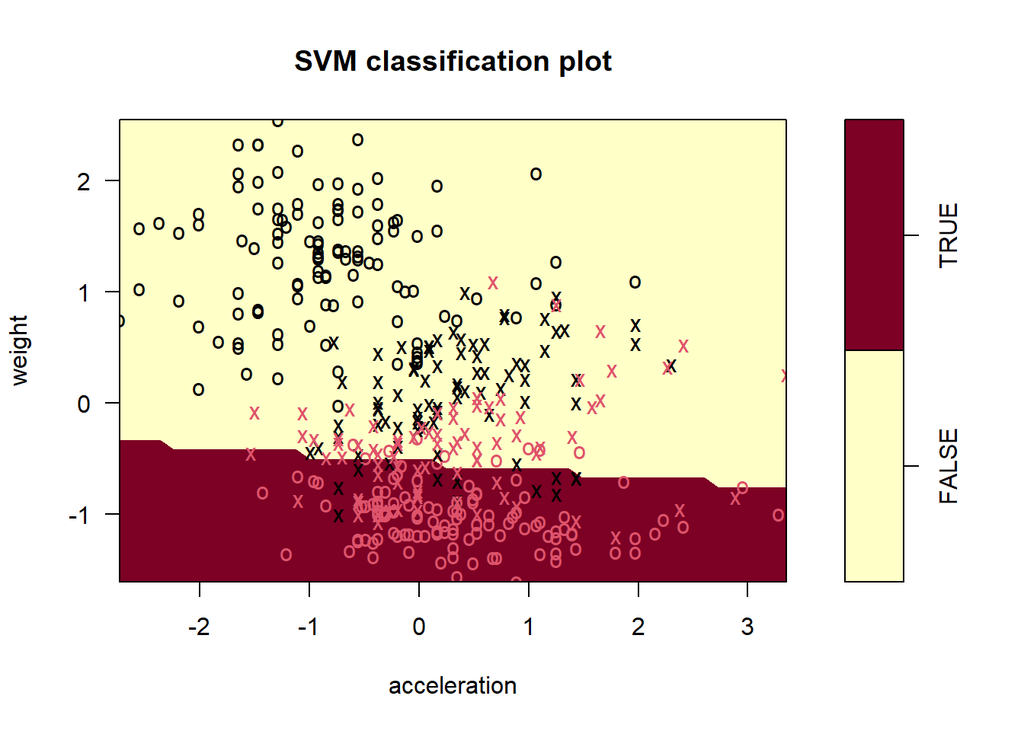

```r
plot(bestmod, Auto, weight~acceleration)
```

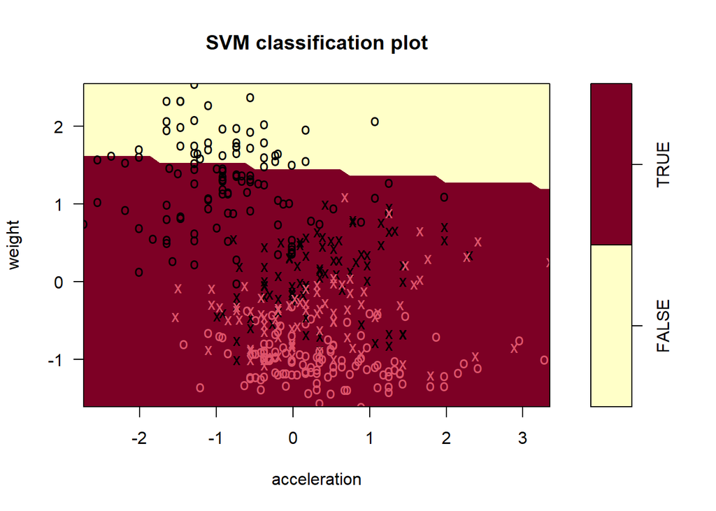

```r
plot(bestmod, Auto, weight~acceleration, slice=list(displacement=-0.5,
                                               horsepower=-0.5,
                                               year=2,
                                               cylinders=0,
                                               origin=0))
```

Now, it looks like the model is predicting that most of the cars will have good gas mileage. Obviously, this is misleading- but it does serve as a good reminder of why we can’t project a 7-dimensional space into 2 dimensions and expect to extract much useful information!

## Polynomial Support Vector Machine

### Model

The polynomial support vector machine (SVM) is the same as the linear SVC, but with a polynomial boundary between the regions instead of a linear one. The syntax to make the model is the same as in the linear case; however, for this model, we will cross-validate to find the degree of the polynomial in addition to the cost.

```r
polysvm <- tune(svm, binaryMPG~., data=Auto, kernel='polynomial',
                ranges=list(cost=c(0.001, 0.01, 0.1, 1, 5, 10, 100),
                            degree=c(2,3,4,5)))
summary(polysvm)
```

```
##
## Parameter tuning of 'svm':
##
## - sampling method: 10-fold cross validation
##
## - best parameters:
##  cost degree
##    10      3
##
## - best performance: 0.07153846
##
## - Detailed performance results:
##     cost degree      error dispersion
## 1  1e-03      2 0.54339744 0.02974011
## 2  1e-02      2 0.42346154 0.06158014
```

[output cut: 26 more lines]

A polynomial support vector machine applies the polynomial to support vectors, not features. Therefore, a higher-order polynomial does not result in a larger feature space or more complex model. This means we do not need to use the one-standard-deviation rule to determine the best model. Instead, we use the same code as above:

```r
bestpoly <- polysvm$best.model
summary(bestpoly)
```

```
##
## Call:
## best.tune(method = svm, train.x = binaryMPG ~ ., data = Auto, ranges = list(cost = c(0.001,
##     0.01, 0.1, 1, 5, 10, 100), degree = c(2, 3, 4, 5)), kernel = "polynomial")
##
##
## Parameters:
##    SVM-Type:  C-classification
##  SVM-Kernel:  polynomial
##        cost:  10
##      degree:  3
##      coef.0:  0
##
## Number of Support Vectors:  99
##
##  ( 49 50 )
##
##
## Number of Classes:  2
##
## Levels:
##  FALSE TRUE
```

### Plots

We can make another plot:

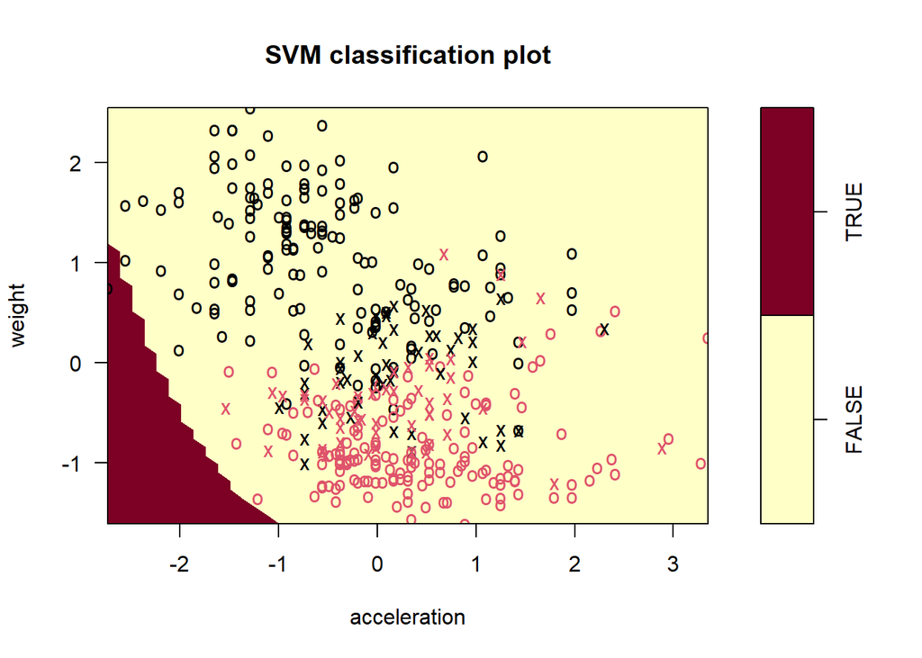

```r
plot(bestpoly, Auto, weight~acceleration)
```

Although the plotted boundary still does not accurately reflect the model predictions, we can see that the shape is curved, instead of linear.

## Radial Support Vector Machine

### Model

Finally, a radial kernel may be used to draw a closed shape around one class of observations. Again, the syntax is the same as before, but this time we will also add cross-validation to find the optimal gamma. Gamma is a tuning parameter that determines the effect that neighboring observations will have on classifying the observation in question. If gamma is large, then distant observations will have almost no effect on the classification. If gamma is small, then more distant observations may affect the final prediction.

```r
radsvm <- tune(svm, binaryMPG~., data=Auto, kernel='radial',
                ranges=list(cost=c(0.001, 0.01, 0.1, 1, 5, 10, 100),
                            gamma=c(0.5,1,2,3,4)))
summary(radsvm)
```

```
##
## Parameter tuning of 'svm':
##
## - sampling method: 10-fold cross validation
##
## - best parameters:
##  cost gamma
##     1   0.5
##
## - best performance: 0.06884615
##
## - Detailed performance results:
##     cost gamma      error dispersion
## 1  1e-03   0.5 0.56121795 0.03949843
## 2  1e-02   0.5 0.56121795 0.03949843
```

[output cut: 33 more lines]

```r
bestrad <- radsvm$best.model
summary(bestrad)
```

```
##
## Call:
## best.tune(method = svm, train.x = binaryMPG ~ ., data = Auto, ranges = list(cost = c(0.001,
##     0.01, 0.1, 1, 5, 10, 100), gamma = c(0.5, 1, 2, 3, 4)), kernel = "radial")
##
##
## Parameters:
##    SVM-Type:  C-classification
##  SVM-Kernel:  radial
##        cost:  1
##
## Number of Support Vectors:  125
##
##  ( 64 61 )
##
##
## Number of Classes:  2
##
## Levels:
##  FALSE TRUE
```

### Plots

Again, a plot:

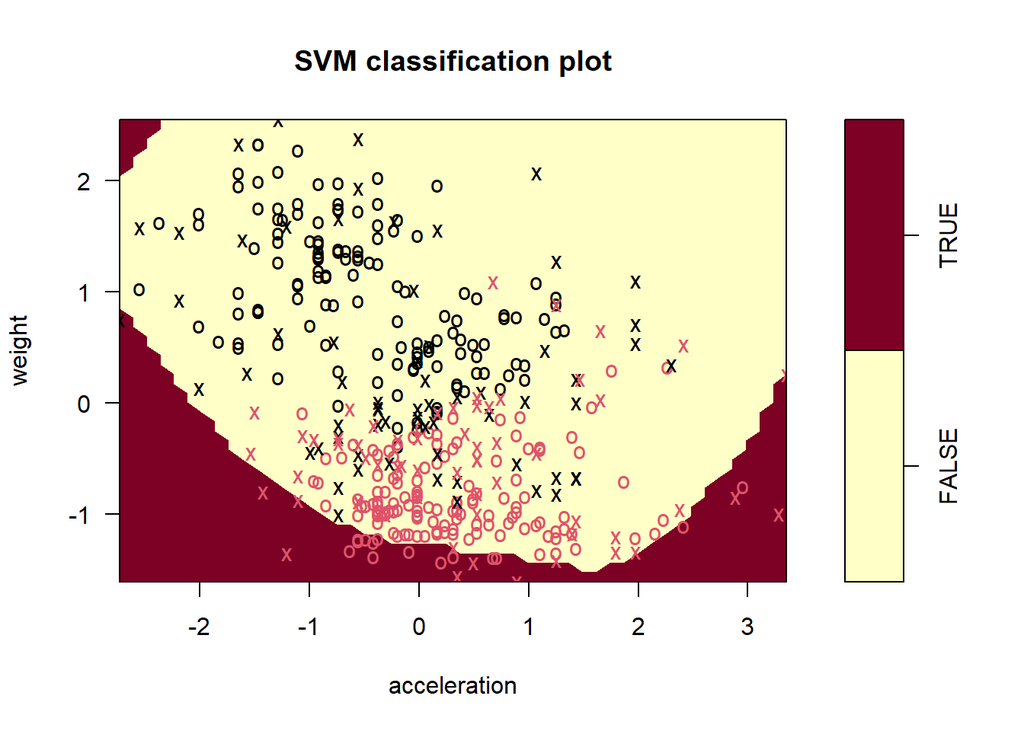

```r
plot(bestrad, Auto, weight~acceleration)
```

Here, we can see the radial SVM boundary.